# 20221029：京都訪問

Takala

プライベートで京都を訪問中．前回8月に来た時よりもかなり人が多くなっている印象．海外の方も少なくない数目に入り，鎖国が終わったことを感じる．

今回はバスでの移動がメインだったが，かなり混んでいて疲れた． 疲れたが，バスの車内に「京都市バスは95パーセントの路線で赤字なので，バスの利用を増やしてください」という旨の張り紙がありイラっとした．

もちろん赤字路線もあるだろうが，これだけ混んでいる車内に「赤字なので，もっと乗ってください」と書かれてもまったく応援したい気持ちにならない．経営下手くそなのでは？と思ってしまう． しかもイラ立つことに，以下の営業係数の詳細のページを見ると，市バス全体では黒字なのである：

[京都市交通局：令和3年度市バス営業係数について](https://www.city.kyoto.lg.jp/kotsu/page/0000289497.html)

京都市はそもそも市の財政が厳しいという話もある．宗教施設が多いため地方税収が入りにくいという事情はあるが，これだけの規模の都市で観光資源も豊富なのに，財政が厳しいというのは，他の地方都市に対してかなり甘えているのではと考えたくなる．

混雑する車内，ひどい渋滞に，腹立たしい広告．これが京都なのか．

マイナスの感情で締めくくるのも気分が悪いので，おもしろい食べ物をひとつ紹介．

京都祗園名物「壹錢洋食」の壹錢洋食というものだ：

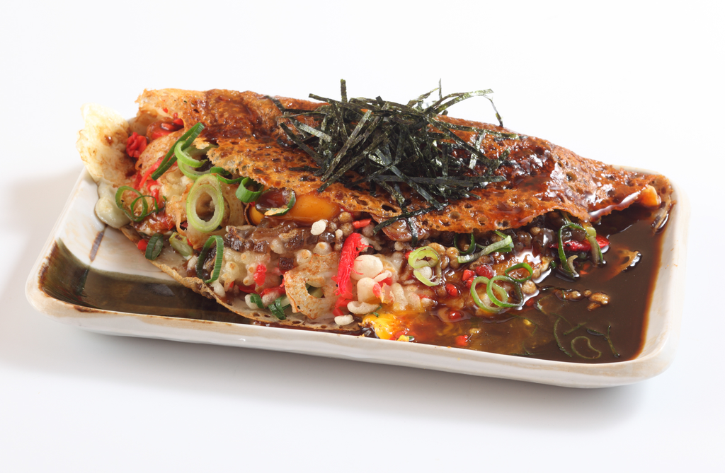

壹錢洋食

お好み焼きのようなものである．詳細は[壹錢洋食について | 京都祗園名物「壹錢洋食」](https://issen-yosyoku.co.jp/aboutissen/)．

はじめて食べたが，ジャンキーな感じでおいしかった．ビールが飲みたくなる味．